# Eigenvalue analysis for Chris

In my committee meeting, Chris questioned whether the gopher/black-and-yellow cluster wouldn’t separate more solidly by with two of the other principal components in the analysis. This is a fair point, and one that I should demonstrate empirically.

```r
library(tidyverse)
library(adegenet)
library("ape")
library("pegas")
library(RColorBrewer)
```

## PCA trying to separate chrysomelas and carnatus

Read in genepop file for just gopher and black-and-yellow

```r
gby1 <- read.genepop("../new_baseline_data/processed/only_carnatus_chrysomelas.gen", ncode = 3)
```

```
 Converting data from a Genepop .gen file to a genind object...


File description:  Title line:"downsampled_sebastes_genepop3d"
```

```
Duplicate individual names detected. Coercing them to be unique.
```

```
...done.
```

```r
# set population as a factor
gby1@pop <- as.factor(gby1@pop)
```

PCA with just GBY using adegenet

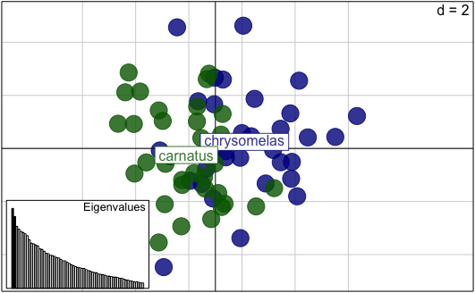

```r
# Allele presence absence data are extracted and NAs replaced using tab:
gby1X <- tab(gby1, NA.method="mean")
# make PCA
gby1_pca1 <- dudi.pca(gby1X, center = TRUE, scannf = FALSE, scale=FALSE, nf = 100)
# plot with factor labels
#pdf("pdf_outputs/carnatus_chrysomelas_pca.pdf", width = 10, height = 10)
s.class(gby1_pca1$li, fac=pop(gby1), cell = 0,
        xax=1, yax=2, col=transp(c("dark blue", "dark green"),.8),
        axesel=FALSE, cstar=0, cpoint=4)
add.scatter.eig(gby1_pca1$eig[1:63],3,1,2, ratio=.3)
```

```r
#dev.off()
```

```r
gby1_pca1$eig
```

```
 [1] 3.9355170 3.5357756 3.0517497 2.9103616 2.8091214 2.7545423
 [7] 2.6843868 2.5919501 2.3910355 2.2319773 2.1917139 2.1404927
[13] 2.0891670 1.9434236 1.9207218 1.8293735 1.7304243 1.7074451
[19] 1.6320189 1.6139290 1.5757098 1.5178669 1.4942984 1.4267774
[25] 1.3579245 1.3544907 1.2827641 1.2267259 1.1649718 1.1188702
[31] 1.0670291 1.0351834 1.0125551 0.9865278 0.9820560 0.9240376
[37] 0.8784754 0.8516264 0.8047233 0.7793690 0.7701904 0.7058712
[43] 0.6922137 0.6794048 0.6484386 0.6087867 0.6032908 0.5813923
[49] 0.5601602 0.5546017 0.5330120 0.5003972 0.4923051 0.4528192
[55] 0.4182426 0.4017290 0.3679075 0.3501194 0.3226834 0.3180892
[61] 0.3011047 0.2725486 0.2637787
```

For these two species, there are 63 eigenvalues

Using the adegenet manual to describe the PC variance in terms of percentage of the total variance:

```r
sum(eig.perc[1:30])
```

```
[1] 74.71121
```

[output not shown]

[output cut: 54 more lines]

Let’s see if plotting any of the other PCs will separate gopher/black-and-yellow.

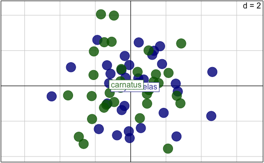

```r
# PC 2 and 3
s.class(gby1_pca1$li, fac=pop(gby1), cell = 0,
        xax=2, yax=3, col=transp(c("dark blue", "dark green"),.8),
        axesel=FALSE, cstar=0, cpoint=4)
add.scatter.eig(gby1_pca1$eig[1:63],3,2,3, ratio=.3)
```

```r
#dev.off()
```

Here I’ll cycle over the sets of sequential PCs, e.g. PC1 and PC2, PC2 and PC3, etc.

```r
pdf("pdf_outputs/carnatus_chrysomelas_pca_tile.pdf", width = 10, height = 10)
par(mfrow = c(3,3))
# name a vector for the first 20 PCs
a <- 1:10
for (i in seq_along(a)) {
s.class(gby1_pca1$li, fac=pop(gby1), cell = 0,
        xax=a[i], yax=a[i+1], col=transp(c("dark blue", "dark green"),.8),
        axesel=FALSE, cstar=0, cpoint=4)
add.scatter.eig(gby1_pca1$eig[1:63],3,a[i],a[i+1], ratio=.3)
}
```

```
Error in `[.data.frame`(dfxy, , yax) : undefined columns selected
```

```
Error in `[.data.frame`(dfxy, , yax) : undefined columns selected
```

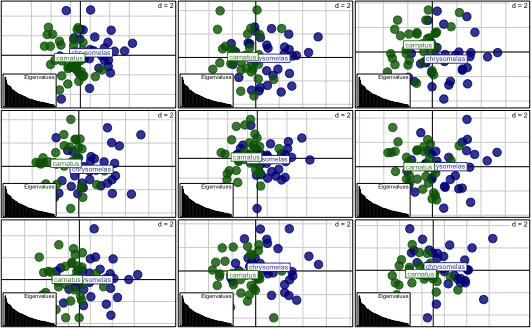

```r
# using PC1 as the x axis in each case
par(mfrow = c(3,3))
for (i in seq_along(a)) {
s.class(gby1_pca1$li, fac=pop(gby1), cell = 0,
        xax=1, yax=a[i+1], col=transp(c("dark blue", "dark green"),.8),
        axesel=FALSE, cstar=0, cpoint=4)
add.scatter.eig(gby1_pca1$eig[1:63],3,1,a[i+1], ratio=.3)
}
```

# Using PC 2 as the x-axis in each plot

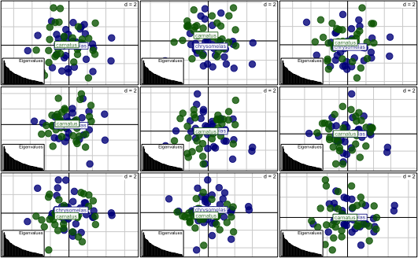

```r
par(mfrow = c(3,3))
a <- 3:11
for (i in seq_along(a)) {
s.class(gby1_pca1$li, fac=pop(gby1), cell = 0,
        xax=2, yax=a[i], col=transp(c("dark blue", "dark green"),.8),
        axesel=FALSE, cstar=0, cpoint=4)
add.scatter.eig(gby1_pca1$eig[1:63],3,1,a[i+1], ratio=.3)
}
```

## Mean of the values of each PC for gopher/black-and-yellow

Another way to look at these data is by calculating the mean of the values of each PC for all the gopher individuals and all of the black-and-yellow individuals.

And then plot those means on the y-axis, with the x-axis showing which principal component it is. I suspect that this will show some separation in the means from the first principal component, and very little after that for any of the others.

```r
gby1$pop
```

```
 [1] chrysomelas chrysomelas chrysomelas chrysomelas chrysomelas
 [6] chrysomelas chrysomelas chrysomelas chrysomelas chrysomelas
[11] chrysomelas chrysomelas chrysomelas chrysomelas chrysomelas
[16] chrysomelas chrysomelas chrysomelas chrysomelas chrysomelas
[21] chrysomelas chrysomelas chrysomelas chrysomelas chrysomelas
[26] chrysomelas chrysomelas chrysomelas chrysomelas chrysomelas
[31] chrysomelas chrysomelas carnatus    carnatus    carnatus
[36] carnatus    carnatus    carnatus    carnatus    carnatus
[41] carnatus    carnatus    carnatus    carnatus    carnatus
[46] carnatus    carnatus    carnatus    carnatus    carnatus
[51] carnatus    carnatus    carnatus    carnatus    carnatus
[56] carnatus    carnatus    carnatus    carnatus    carnatus
[61] carnatus    carnatus    carnatus    carnatus
Levels: chrysomelas carnatus
```

There we can see that samples 1-32 are chrysomelas and 33-64 are carnatus.

What I want is to take the mean of each column for the first 32 samples and then the mean of each column for the 33-64 samples.

```r
# turn df into a tibble,
# sort by the species groups, and then
# calculate the mean
gby_pc_means <- rownames_to_column(gby1_pca1$li, var = "id") %>%
  mutate(species = ifelse(id < 33, "chrysomelas", "carnatus")) %>%
  group_by(species) %>%
  summarise_all(funs(mean))
```

```
argument is not numeric or logical: returning NAargument is not numeric or logical: returning NA
```

```r
gby_pc_means
```

| species | id | Axis1 | Axis2 | Axis3 | Axis4 | Axis5 | Axis6 | Axis7 | Axis8 | Axis9 | Axis10 | Axis11 | Axis12 | Axis13 | Axis14 | Axis15 | Axis16 | Axis17 | Axis18 | Axis19 | Axis20 | Axis21 | Axis22 | Axis23 | Axis24 | Axis25 | Axis26 | Axis27 | Axis28 | … |
| --- | --- | --- | --- | --- | --- | --- | --- | --- | --- | --- | --- | --- | --- | --- | --- | --- | --- | --- | --- | --- | --- | --- | --- | --- | --- | --- | --- | --- | --- | --- |
| carnatus | NA | -1.094812 | -0.2471961 | 0.07009373 | 0.5788552 | 0.2575379 | 0.1314194 | 0.0008138304 | 0.01610894 | -0.3167685 | -0.3122577 | -0.002308615 | 0.2227198 | 0.05867678 | 0.00671139 | 0.2928229 | 0.2406508 | 0.03186666 | -0.07095864 | 0.04001294 | -0.1039552 | -0.1195198 | 0.1114992 | -0.0180968 | 0.1017423 | -0.1945439 | 0.02383374 | 0.006706939 | -0.09268044 | … |
| chrysomelas | NA | 1.094812 | 0.2471961 | -0.07009373 | -0.5788552 | -0.2575379 | -0.1314194 | -0.0008138304 | -0.01610894 | 0.3167685 | 0.3122577 | 0.002308615 | -0.2227198 | -0.05867678 | -0.00671139 | -0.2928229 | -0.2406508 | -0.03186666 | 0.07095864 | -0.04001294 | 0.1039552 | 0.1195198 | -0.1114992 | 0.0180968 | -0.1017423 | 0.1945439 | -0.02383374 | -0.006706939 | 0.09268044 | … |

So then I want to plot those means on the y-axis and have PC on the x-axis.

```r
as.numeric(mean_df$pc)
```

```
  [1]  1  1  2  2  3  3  4  4  5  5  6  6  7  7  8  8  9  9 10 10 11 11
 [23] 12 12 13 13 14 14 15 15 16 16 17 17 18 18 19 19 20 20 21 21 22 22
 [45] 23 23 24 24 25 25 26 26 27 27 28 28 29 29 30 30 31 31 32 32 33 33
 [67] 34 34 35 35 36 36 37 37 38 38 39 39 40 40 41 41 42 42 43 43 44 44
 [89] 45 45 46 46 47 47 48 48 49 49 50 50 51 51 52 52 53 53 54 54 55 55
[111] 56 56 57 57 58 58 59 59 60 60 61 61 62 62 63 63
```

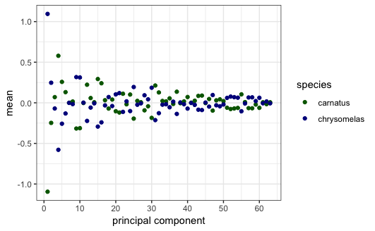

```r
mean_plot <- mean_df %>%
  ggplot() +
  geom_point(aes(x = pc, y = mean, color = species)) +
  theme_bw() +
  scale_color_manual(values = c("dark green", "dark blue"))
mean_plot +
  scale_x_continuous(name = "principal component", breaks=seq(0,65,10), labels=seq(0,65,10))
ggsave("pdf_outputs/gby_pc_means.pdf")
```

Based on the data, PC1 x PC4 might be the best bet?

```r
pdf("pdf_outputs/carnatus_chrysomelas_pc1xpc4.pdf", width = 10, height = 10)
s.class(gby1_pca1$li, fac=pop(gby1), cell = 0,
        xax=1, yax=4, col=transp(c("dark blue", "dark green"),.8),
        axesel=FALSE, cstar=0, cpoint=4)
add.scatter.eig(gby1_pca1$eig[1:63],3,1,4, ratio=.3)
```

```r
dev.off()
```

## Fst

```r
library(hierfstat)
```

```r
fst_gby <- pairwise.fst(gby1, pop = gby1$pop, res.type = c("matrix"))
fst_gby
```

```
            chrysomelas   carnatus
chrysomelas  0.00000000 0.01568309
carnatus     0.01568309 0.00000000
```

This isn’t properly accounting for the two species. Not sure why not.

```r
gby1
```

```
/// GENIND OBJECT /////////

 // 64 individuals; 90 loci; 503 alleles; size: 218.9 Kb

 // Basic content
   @tab:  64 x 503 matrix of allele counts
   @loc.n.all: number of alleles per locus (range: 1-18)
   @loc.fac: locus factor for the 503 columns of @tab
   @all.names: list of allele names for each locus
   @ploidy: ploidy of each individual  (range: 2-2)
   @type:  codom
   @call: read.genepop(file = "../new_baseline_data/processed/only_carnatus_chrysomelas.gen",
    ncode = 3)

 // Optional content
   @pop: population of each individual (group size range: 32-32)
```